# Midterm-Report

## 1 Introduction

### 1.1 Backgroud

When talking about 2020, “COVID-19”, a novel coronavirus firstly found in Wuhan, China, in the end of 2019 (Mclntosh, 2020), must be the most popular word that appears on the Internet, newspapers and daily conversations. Since COVID-19 has been discovered and claimed as human pandemic by Chinese government, there are more than 36 millions of people being confirmed with COVID-19 and about 1 million deaths by now (2020). COVID-19 is definitely raising a huge concern of public health around the world.

### 1.2 Problem Statement

There are many opinions about the origin of COVID-19. Some suggests that the sequence of COVID-19 is similar to bat virus (Shin, 2020), while others do not support that idea. There are also many unclear characteristics about this new virus. Therefore, this report will mainly focus on discovering main and critical characteristics of COVID-19, including incubation period, COVID-19 distribution of age, gender.

### 1.3 Data Discription

This data is obtained from Kaggle: Novel Corona Virus 2019 Data set. These COVID-19 case data are collected from 20th January to 28th February, 2020, which is the early pandemic period of COVID-19. This data set consists of 10 qualitative attributes, 7 quantitative attributes and 3 other attributes (Table1.1).

Table1.1 Description of COVID-19 data set

| Variable Name | Discription |
| --- | --- |
| id | Patient ID |
| case_in_county | Number of case in county |
| reporting date | Case reporting date |
| summary | Patient summary discription |
| location | Location |
| country | Country |
| gender | Gender |
| age | Age |
| sympton_onset | Sympton onset date |
| if_onset_approximated | Whether symptom onset is approximated |
| hosp_visit_date | hospotal visiting date |
| exposure_start | Exposure start date |
| exposure_end | Exposure end date |
| visiting Wuhan | Whether the patient visted Wuhan |
| from Wuhan | Whether the patient is from Wuhan |
| death | Whether the patient died |
| recovered | Whether the patient recovered |
| symptom | Symptom |
| source | Source of the patient’s information |
| link | Source link |

## 2 Methodology

The data set that is used in this report is downloaded from a Kaggle page. It offers day-level information and data set on COVID-19 affected cases. First, basic statistics of variables will be computed. Second, basic plots, for instance, box plot, line plot and histograms will be drawn to give ideas of how each variables are distributed. Then, missing value will be evaluated and necessary substitution or deletion of missing value will be used for each variables. Specifically, the following method will be used to deal with specific variable:

1. If a row has all NA in most of the columns, it will be deleted;
2. Missing values in “location”, “gender” and “country” will not be imputed;
3. Missing values in “age” will be generated using the mean of “age”;
4. Missing values in “hosp visit date” will be imputed by it’s “reporting date”;
5. Missing value in “symptom onset date” will be imputed by the average of the difference between “symptom onset data” and “hosp visit date”;
6. Missing value in “exposure start data” will be imputed by the average of the difference between “exposure start data” and “symptom onset date”;
7. Missing value in “exposure end data” will be imputed by “hosp visit data”.
8. Missing value in “symptoms” will be imputed by the most frequent symptoms.

In the later steps, time-series plot of COVID-19 cases will be drawn to see how the case number increases by time. Age-specific, gender-specific, country-specific confirm rate will be compared.

## 3 Results

In the beginning, 3 descriptive variables “summary”, “source” and “link” will be excluded and the main data set will have 17 variables and 1085 observations.The following table listed some descriptive statistics about main variables in COVID-19 data set.

Table3.1 Descriptive statistics of main variables in COVID-19 data set

[output not shown]

In order to avoid problems when analyzing sparse data set, different methods of imputing missing values were used to deal with variables individually.

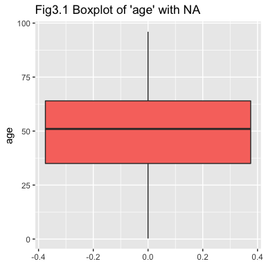

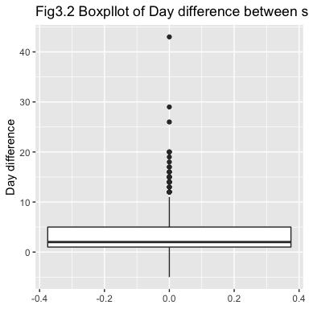

4. The mean difference between exposure start date and symptom onset date is 12 (Fig3.3). Then, the missing values in “exposure start” are imputed by “symptom onset” minus 12 days.

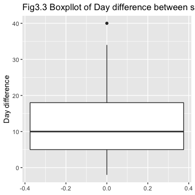

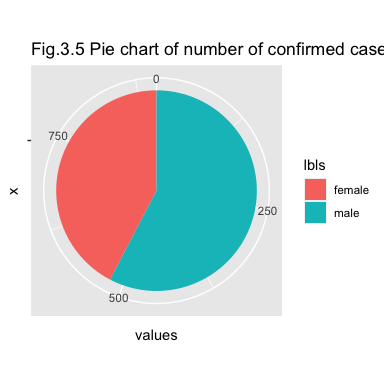

## Reference

https://www.uptodate.com/contents/coronavirus-disease-2019-covid-19-epidemiology-v

irology-and-prevention

https://medium.com/microbial-instincts/the-latest-theory-that-may-answer-the-origin-of-covid-19-d9efbe7072ae

View [here](https://ghcdn.rawgit.org/shiyushen/PM566-Project/master/Midterm.html)